# Proyecto final

Predicción del precio del Bitcoin y Ethereum utilizando series de tiempo.

Edwin Flores

2021-04-07

# 1 **Compresión del negocio**

Sin duda alguna, los meses anteriores han sido muy importantes en la bolsa de criptomonedas debido al alza continua, principalmente del Bitcoin. Noticias van y vienen sobre este tema y esto genera muchas dudas en las personas que quieren invertir en este tipo de activos. Teniendo en cuenta lo anterior, el proyecto trata de predecir el precio de dos criptomonedas, Bitcoin y Ethereum, debido a que estás se encuentran entre las criptomonedas de mejor rendimiento y que han tenido un alza importante en los últimos meses. Para esto será necesario aplicar los conocimientos obtenidos del programa de minería de datos, específicamente en el área de series de tiempo.

## 1.1 **Objetivo General**

- Predecir el precio de criptomonedas del Bitcoin y Ethereum en dólares

## 1.2 **Objetivos específicos**

- Utilizar la mayor cantidad de métodos predictivos para series de tiempo vistos en clase, y compararlos.
- Seleccionar el mejor método de predicción para Bitcoin como para Ethereum.

# 2 **Compresión de los datos**

El historial de datos a utilizar comprende desde el 17 de septiembre 2014 a la fecha para Bitcoin y desde 7 de agosto del 2015 a la fecha para el Ethereum.

Las variables (columnas) en ambas tablas de datos serían las siguientes:  
a. Date  
b. Open  
c. High  
d. Low  
e. Close  
f. Adj Close  
g. Volume

Los individuos (filas) comprenden información histórica diaria desde 2014 para Bitcoin y desde 2015 para Ethereum

Para la tabla de datos, la cual comprende información histórica diaria del Bitcoin, la dimensión sería de 2,332 individuos y 7 variables. Mientras para la tabla de datos, la cual comprende información histórica diaria del Ethereum, la dimensión sería de 2,008 individuos y 7 variables.

La variable a predecir tanto para el Bitcoin como para el Ethereum sería la variable Close. Esto porque, es la variable que indica cual fue el precio en que el cerraron estas criptomonedas en la bolsa.

## 2.1 **Recolección de los datos**

La recolección de datos se realiza desde la plataforma de *yahoo finance*, especificamente de las siguientes páginas web.  
a. https://finance.yahoo.com/quote/BTC-USD

[figure not shown]

Bitcoin

b. https://finance.yahoo.com/quote/ETH-USD

[figure not shown]

Ethereum

# 3 **Bitcoin (BTC)**

## 3.1 **Descripción de los datos**

### 3.1.1 Carga de datos

```r
library(DT)
Sys.setlocale("LC_TIME", "Spanish")
```

```
## [1] "Spanish_Spain.1252"
```

```r
dataset.btc <- read.csv(file = "datos/BTC-USD.csv", head = TRUE, sep=",")
DT::datatable(dataset.btc)
```

|  | Date | Open | High | Low | Close | Adj.Close | Volume |
| --- | --- | --- | --- | --- | --- | --- | --- |
| 1 | 2014-09-17 | 465.864014 | 468.174011 | 452.421997 | 457.334015 | 457.334015 | 21056800 |
| 2 | 2014-09-18 | 456.859985 | 456.859985 | 413.104004 | 424.440002 | 424.440002 | 34483200 |
| 3 | 2014-09-19 | 424.102997 | 427.834991 | 384.532013 | 394.795990 | 394.795990 | 37919700 |
| 4 | 2014-09-20 | 394.673004 | 423.295990 | 389.882996 | 408.903992 | 408.903992 | 36863600 |
| 5 | 2014-09-21 | 408.084991 | 412.425995 | 393.181000 | 398.821014 | 398.821014 | 26580100 |
| 6 | 2014-09-22 | 399.100006 | 406.915985 | 397.130005 | 402.152008 | 402.152008 | 24127600 |
| 7 | 2014-09-23 | 402.092010 | 441.557007 | 396.196991 | 435.790985 | 435.790985 | 45099500 |
| 8 | 2014-09-24 | 435.751007 | 436.112000 | 421.131989 | 423.204987 | 423.204987 | 30627700 |
| 9 | 2014-09-25 | 423.156006 | 423.519989 | 409.467987 | 411.574005 | 411.574005 | 26814400 |
| 10 | 2014-09-26 | 411.428986 | 414.937988 | 400.009003 | 404.424988 | 404.424988 | 21460800 |

[output cut: 2322 more lines]

```r
frecuency_parameter = 12
```

Seguidamente se presentará la descripción de los datos para ambas criptomonedas.

## 3.2 **Exploración de los datos**

### 3.2.1 Exploración de los datos

```r
summary(dataset.btc)
```

```
##          Date                Open                High                Low
##  2014-09-17:   1   null        :   4   null        :   4   null        :   4
##  2014-09-18:   1   17760.300781:   2   244.251007  :   2   429.076996  :   2
##  2014-09-19:   1   233.421997  :   2   267.002991  :   2   10000.708008:   1
##  2014-09-20:   1   314.079010  :   2   6536.919922 :   2   10008.789063:   1
##  2014-09-21:   1   376.756989  :   2   1002.099976 :   1   1001.580017 :   1
##  2014-09-22:   1   10024.115234:   1   10021.744141:   1   10017.250977:   1
##  (Other)   :2326   (Other)     :2319   (Other)     :2320   (Other)     :2322
##           Close             Adj.Close           Volume
##  null        :   4   null        :   4   null      :   4
##  1179.969971 :   2   1179.969971 :   2   1002120000:   1
##  236.153000  :   2   236.153000  :   2   100390000 :   1
##  6741.750000 :   2   6741.750000 :   2   100484000 :   1
##  10005.000000:   1   10005.000000:   1   100607000 :   1
##  10019.716797:   1   10019.716797:   1   100665000 :   1
##  (Other)     :2320   (Other)     :2320   (Other)   :2323
```

```r
str(dataset.btc)
```

```
## 'data.frame':    2332 obs. of  7 variables:
##  $ Date     : Factor w/ 2332 levels "2014-09-17","2014-09-18",..: 1 2 3 4 5 6 7 8 9 10 ...
##  $ Open     : Factor w/ 2325 levels "10024.115234",..: 1345 1326 1224 1095 1144 1106 1117 1266 1219 1157 ...
##  $ High     : Factor w/ 2326 levels "1002.099976",..: 1370 1336 1236 1213 1160 1129 1286 1271 1214 1166 ...
##  $ Low      : Factor w/ 2328 levels "10000.708008",..: 1299 1168 1052 1076 1092 1105 1101 1207 1147 1116 ...
##  $ Close    : Factor w/ 2326 levels "10005.000000",..: 1330 1232 1098 1148 1110 1123 1269 1223 1161 1136 ...
##  $ Adj.Close: Factor w/ 2326 levels "10005.000000",..: 1330 1232 1098 1148 1110 1123 1269 1223 1161 1136 ...
##  $ Volume   : Factor w/ 2329 levels "1002120000","100390000",..: 717 1242 1343 1307 985 885 1555 1117 994 738 ...
```

## 3.3 **Preparación de los datos**

### 3.3.1 Formateo de los datos

```r
library(lubridate)

dataset.btc[dataset.btc == 'null'] <- NA
dataset.btc$Date      <- ymd(dataset.btc$Date)
dataset.btc$Open      <- as.numeric(as.character(dataset.btc$Open))
dataset.btc$High      <- as.numeric(as.character(dataset.btc$High))
dataset.btc$Low       <- as.numeric(as.character(dataset.btc$Low))
dataset.btc$Close     <- as.numeric(as.character(dataset.btc$Close))
dataset.btc$Adj.Close <- as.numeric(as.character(dataset.btc$Adj.Close))
dataset.btc$Volume    <- as.numeric(as.character(dataset.btc$Volume))
DT::datatable(dataset.btc)
```

|  | Date | Open | High | Low | Close | Adj.Close | Volume |
| --- | --- | --- | --- | --- | --- | --- | --- |
| 1 | 2014-09-17 | 465.864014 | 468.174011 | 452.421997 | 457.334015 | 457.334015 | 21056800 |
| 2 | 2014-09-18 | 456.859985 | 456.859985 | 413.104004 | 424.440002 | 424.440002 | 34483200 |
| 3 | 2014-09-19 | 424.102997 | 427.834991 | 384.532013 | 394.79599 | 394.79599 | 37919700 |
| 4 | 2014-09-20 | 394.673004 | 423.29599 | 389.882996 | 408.903992 | 408.903992 | 36863600 |
| 5 | 2014-09-21 | 408.084991 | 412.425995 | 393.181 | 398.821014 | 398.821014 | 26580100 |
| 6 | 2014-09-22 | 399.100006 | 406.915985 | 397.130005 | 402.152008 | 402.152008 | 24127600 |
| 7 | 2014-09-23 | 402.09201 | 441.557007 | 396.196991 | 435.790985 | 435.790985 | 45099500 |
| 8 | 2014-09-24 | 435.751007 | 436.112 | 421.131989 | 423.204987 | 423.204987 | 30627700 |
| 9 | 2014-09-25 | 423.156006 | 423.519989 | 409.467987 | 411.574005 | 411.574005 | 26814400 |
| 10 | 2014-09-26 | 411.428986 | 414.937988 | 400.009003 | 404.424988 | 404.424988 | 21460800 |

[output cut: 2322 more lines]

### 3.3.2 Correción de fechas e imputación

```r
library(dplyr)

fecha.inicio <- dataset.btc$Date[1]
fecha.final  <- dataset.btc$Date[nrow(dataset.btc)]

total.fechas <- seq(fecha.inicio, fecha.final, by = "day")

faltan.fechas <- total.fechas[!total.fechas %in% dataset.btc$Date]
faltan.fechas
```

```
## Date of length 0
```

```r
dataset.btc <- dplyr::union_all(dataset.btc, data.frame(Date = faltan.fechas))
dataset.btc <- dataset.btc[order(dataset.btc$Date), ]

dataset.btc$Open[is.na(dataset.btc$Open)] <- mean(dataset.btc$Open, na.rm = T)
dataset.btc$High[is.na(dataset.btc$High)] <- mean(dataset.btc$High, na.rm = T)
dataset.btc$Low[is.na(dataset.btc$Low)] <- mean(dataset.btc$Low, na.rm = T)
dataset.btc$Close[is.na(dataset.btc$Close)] <- mean(dataset.btc$Close, na.rm = T)
dataset.btc$Adj.Close[is.na(dataset.btc$Adj.Close)] <- mean(dataset.btc$Adj.Close, na.rm = T)
dataset.btc$Volume[is.na(dataset.btc$Volume)] <- mean(dataset.btc$Volume, na.rm = T)

dataset.btc <- dataset.btc[!(month(dataset.btc$Date) == 2 & day(dataset.btc$Date) == 29), ] #Se eliminan días biciestos
summary(dataset.btc)
```

```
##       Date                 Open              High              Low
##  Min.   :2014-09-17   Min.   :  176.9   Min.   :  211.7   Min.   :  171.5
##  1st Qu.:2016-04-22   1st Qu.:  449.5   1st Qu.:  454.7   1st Qu.:  443.9
##  Median :2017-11-25   Median : 3953.1   Median : 4051.9   Median : 3870.7
##  Mean   :2017-11-25   Mean   : 5348.1   Mean   : 5493.2   Mean   : 5196.0
##  3rd Qu.:2019-06-30   3rd Qu.: 8608.6   3rd Qu.: 8792.5   3rd Qu.: 8364.0
##  Max.   :2021-02-03   Max.   :40788.6   Max.   :41946.7   Max.   :38980.9
##      Close           Adj.Close           Volume
##  Min.   :  178.1   Min.   :  178.1   Min.   :     5914570
##  1st Qu.:  449.1   1st Qu.:  449.1   1st Qu.:    64707725
##  Median : 3955.5   Median : 3955.5   Median :  3378155000
##  Mean   : 5361.8   Mean   : 5361.8   Mean   :  9935645461
##  3rd Qu.: 8628.5   3rd Qu.: 8628.5   3rd Qu.: 16347597216
##  Max.   :40797.6   Max.   :40797.6   Max.   :123320567399
```

```r
dataset.btc <- dataset.btc %>% group_by(Date = floor_date(Date, "month")) %>% summarise(Close = mean(Close))
```

### 3.3.3 Normalidad de la serie

```r
library(ggplot2)
library(tseries)

dia.inicio <- which(dataset.btc$Date == "2014-09-01") # Obtenemos el número de día. 2014-09-17
dia.inicio
```

```
## [1] 1
```

```r
serie.btc <- ts(dataset.btc$Close, frequency = frecuency_parameter, start = c(2014, 9))
#Patrón Estacional Anual. Frecuencia 12. Los datos vienen mensuales

serie.btc
```

```
##             Jan        Feb        Mar        Apr        May        Jun
## 2014
## 2015   248.7825   234.1536   269.0423   235.4915   236.9970   238.0818
## 2016   410.8445   403.2194   416.5258   434.3394   461.9544   642.8691
## 2017   914.9162  1062.5337  1129.3652  1206.6410  1895.3835  2636.2043
## 2018 13085.5581  9472.0012  9040.5571  8033.5966  8450.9977  6793.5077
## 2019  3701.5550  3711.9073  3976.0691  5178.4694  7309.6941  9415.9002
## 2020  8389.2705  9667.5512  6871.0161  7166.6410  9263.1517  9489.2272
## 2021 34703.0534 35291.8633
##             Jul        Aug        Sep        Oct        Nov        Dec
## 2014                         407.1824   364.1489   366.0998   341.2679
## 2015   279.5637   250.7338   233.5955   264.8554   348.8833   424.4645
## 2016   661.3561   579.5852   605.8486   643.5509   726.3491   828.0604
## 2017  2519.4184  3880.9900  4064.8363  5360.0716  7813.1330 15294.2710
## 2018  7146.3500  6700.1299  6610.6750  6485.1187  5404.2502  3717.4883
## 2019 10669.3362 10643.2484  9814.0679  8411.9292  8373.5724  7284.0130
## 2020  9589.8997 11652.3942 10660.1634 11310.4515 16645.7574 21983.1371
## 2021
```

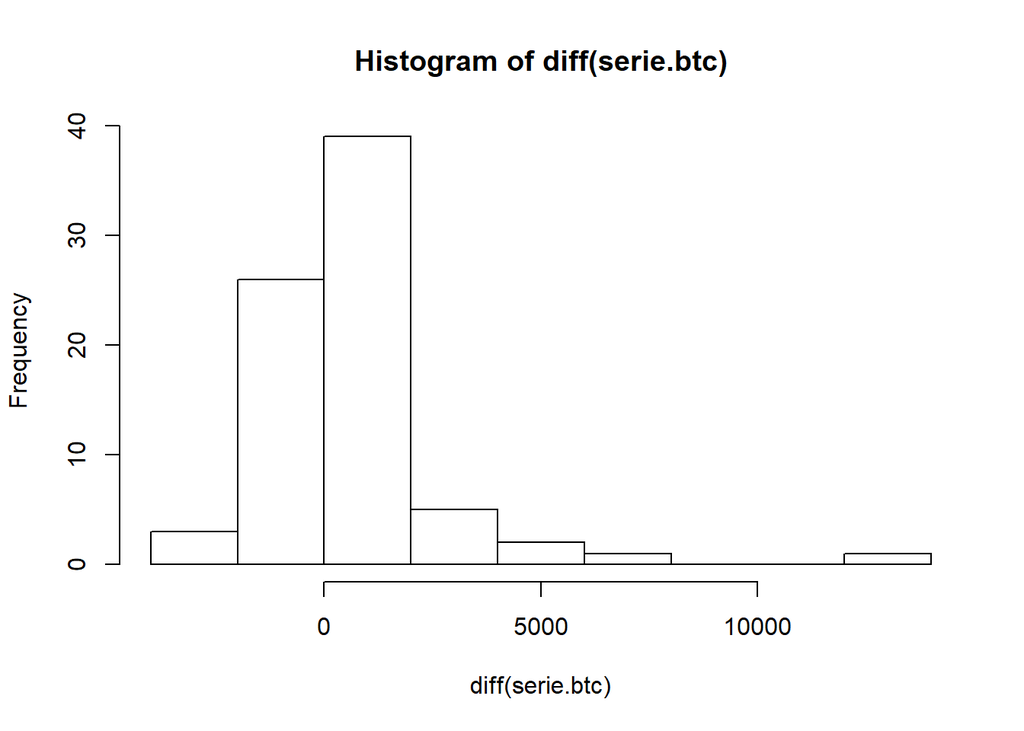

```r
h <- hist(diff(serie.btc), plot = T)
```

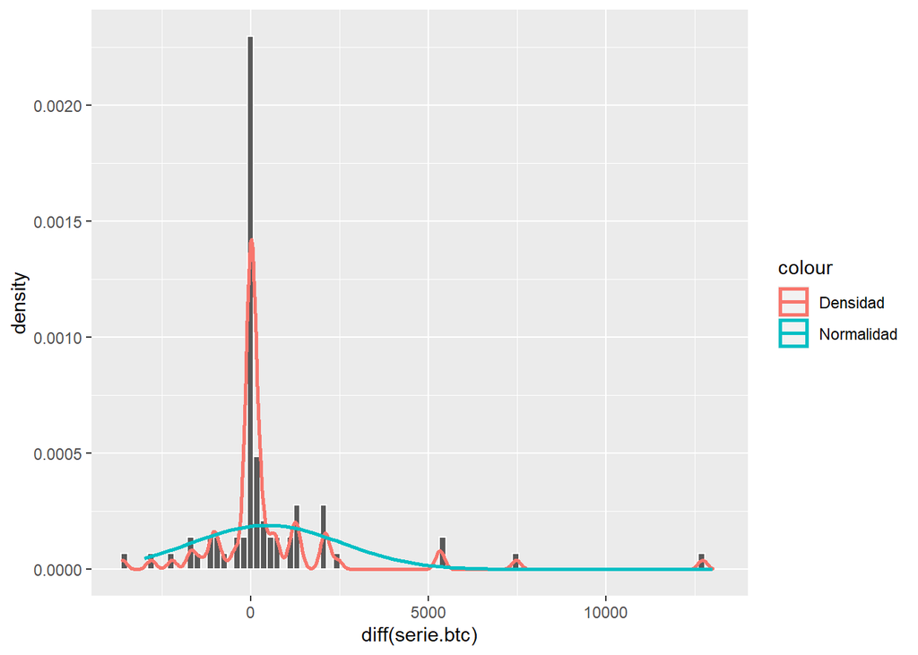

```r
x <- seq(min(h$mids, na.rm = T), max(h$mids, na.rm = T), length = length(serie.btc))
promedio   <- mean(diff(serie.btc), na.rm = T)
desviacion <- sd(diff(serie.btc), na.rm = T)
normalidad <- dnorm(x, promedio, desviacion)

ggplot() +
  geom_histogram(aes(x = diff(serie.btc), y = ..density..), bins = 90, color = "white") +
  geom_density(aes(x = diff(serie.btc), y = ..density.., color = "Densidad"), size = 1) +
  geom_line(aes(x = x, y = normalidad, color = "Normalidad"), size = 1)
```

### 3.3.4 Test qqnorm y test qqline

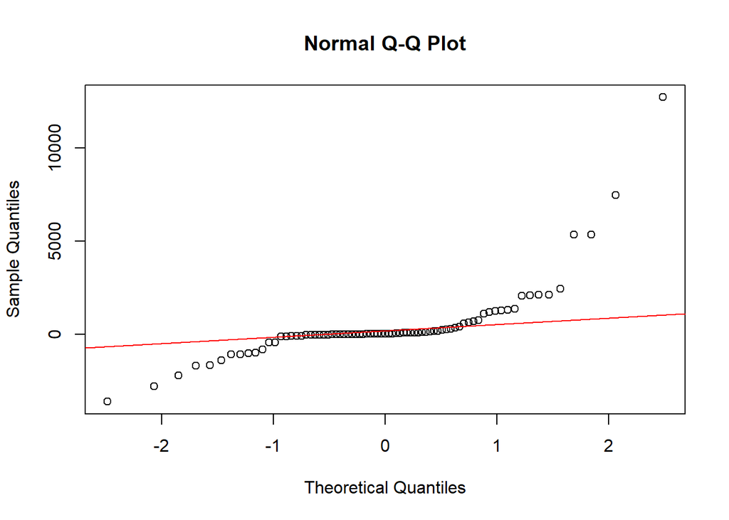

```r
qqnorm(diff(serie.btc))
qqline(diff(serie.btc), col = "red")
```

### 3.3.5 Test de normalidad

- Test chi-square de Pearson

```r
library(nortest)
pearson.test(serie.btc)$p.value
```

```
## [1] 0.0000000000000000003492028
```

- Test Lilliefors (Kolmogorov-Smirnov)

```r
library(nortest)
lillie.test(serie.btc)$p.value
```

```
## [1] 0.000000004230823
```

- Test de Cramer-von Mises

```r
library(nortest)
cvm.test(serie.btc)$p.value
```

```
## [1] 0.00000009400463
```

Los tres tests nos dan un valor de p <= 0.05 (p-value <= 0.05), es decir por debajo del nivel de significancia de 0.05. Por lo que existe evidencia estadística para aceptar la hipotesis de que la muestra *NO* proviene de una distribución normal. Es decir, podemos afirmar que la “serie” no sigue una distribución normal.

### 3.3.6 Descomposición de la serie

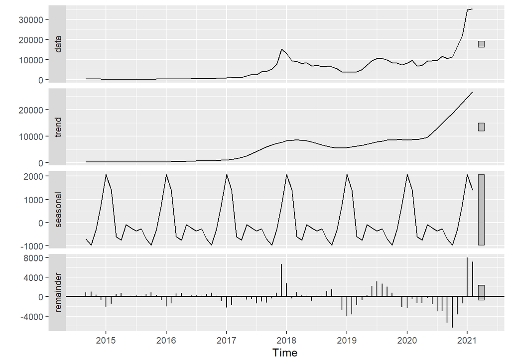

```r
library(forecast)

forecast::autoplot(stl(serie.btc, s.window = "periodic"))
```

### 3.3.7 Periodos más importantes

```r
library(dygraphs)
res <- spec.pgram(serie.btc, log = "no", plot = F)

#Ordena el espectro con respecto a la frecuencia en orden decreciente es decir de mayor a menor,
#el valor 1 no se toma en cuenta pues es toda la serie

max <- order(res$spec, res$freq, decreasing = TRUE)

max <- max[max != 1][1:3] # Ignoramos la posición 1 y tomamos las 3 primeras posiciones.
max
```

```
## [1] 2 4 5
```

```r
# Los periodos más importantes son
periodos <- frecuency_parameter/max
periodos
```

```
## [1] 6.0 3.0 2.4
```

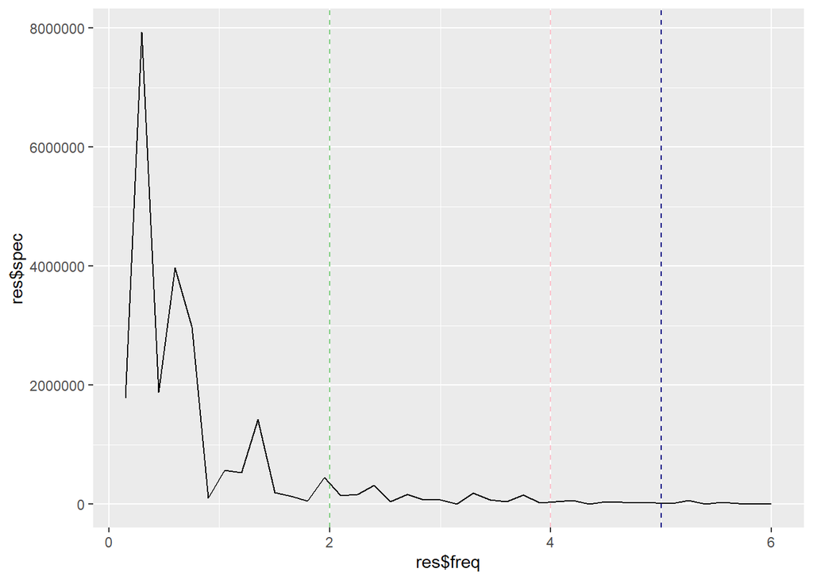

```r
ggplot() + geom_line(aes(x = res$freq, y = res$spec)) +
  geom_vline(xintercept = max[1], linetype = "dashed", color = "palegreen3") +
  geom_vline(xintercept = max[2], linetype = "dashed", color = "pink") +
  geom_vline(xintercept = max[3], linetype = "dashed", color = "navy")
```

```r
dygraph(res, 'Peridiograma', 'Frecuencia', 'Espectro', width = "100%") %>%
  dyEvent(max[1], color = "green") %>%
  dyEvent(max[2], color = "red") %>%
  dyEvent(max[3], color = "navy") %>%
  dyUnzoom() %>%
  dyCrosshair(direction = "vertical") %>%
  dyRangeSelector(height = 20, strokeColor = "black", fillColor = "black", )
```

[interactive chart not shown]

### 3.3.8 Gráfico de la serie

```r
library(dygraphs)
library(xts)

aux <- xts::xts(serie.btc, order.by = as.Date(dataset.btc$Date))
dygraphs::dygraph(aux, main = "Precio del Bitcoin mensual desde el año 2014 al 2021", xlab = "Año", width = "100%") %>%
  dyAxis("y", label = "Precio($)") %>%
  dySeries("V1", label = "Precio($)", color = "#6FC0B3") %>%
  dyLegend(show = "follow") %>%
  dyUnzoom() %>%
  dyCrosshair(direction = "vertical") %>%
  #dyOptions(colors = RColorBrewer::brewer.pal(3, "Set2"))  %>%
  dyRangeSelector(height = 20, strokeColor = "black", fillColor = "black")
```

[interactive chart not shown]

## 3.4 **Modelado**

### 3.4.1 Serie en train y test

```r
serie.btc.train <- head(serie.btc, -frecuency_parameter)
serie.btc.test <- tail(serie.btc, frecuency_parameter)
```

## 3.5 **Construcción de modelado básico**

### 3.5.1 Método promedio

```r
metodo.promedio <- meanf(serie.btc.train, h = frecuency_parameter)
pred.promedio   <- forecast(metodo.promedio, h = frecuency_parameter)
```

### 3.5.2 Método Naive

```r
metodo.naive <- naive(serie.btc.train, h = frecuency_parameter)
pred.naive   <- forecast(metodo.naive, h = frecuency_parameter)
```

### 3.5.3 Método SNaive

```r
metodo.snaive <- snaive(serie.btc.train, h = frecuency_parameter)
pred.snaive   <- forecast(metodo.snaive, h = frecuency_parameter)
```

### 3.5.4 Método Drift

```r
metodo.drift<- rwf(serie.btc.train, h = frecuency_parameter, drift = T)
pred.drift  <- forecast(metodo.drift, h = frecuency_parameter)
```

### 3.5.5 Método STL

```r
metodo.stl <- stl(serie.btc.train, s.window = "periodic")
pred.stl   <- forecast(metodo.stl, h = frecuency_parameter)
```

## 3.6 **Evaluación de modelado básico**

```r
library(xts)
library(forecast)
library(dygraphs)

errores <- tabla.errores(
  predicciones = list(pred.promedio$mean, pred.naive$mean, pred.snaive$mean, pred.drift$mean, pred.stl$mean),
  real = serie.btc.test,
  c("Promedio", "Naive", "S Naive", "Desvio", "Descomposición")
)

errores
```

|  | MSE | RMSE | PFA | PTFA |
| --- | --- | --- | --- | --- |
| Promedio | 224894539 | 14996.48 | 0.00000000 | 0.0000000 |
| Naive | 125470940 | 11201.38 | 0.41666667 | 0.1405812 |
| S Naive | 138414135 | 11764.95 | 0.08333333 | 0.1125597 |
| Desvio | 107794853 | 10382.43 | 0.50000000 | 0.1527050 |
| Descomposición | 120869955 | 10994.09 | 0.41666667 | 0.1507741 |

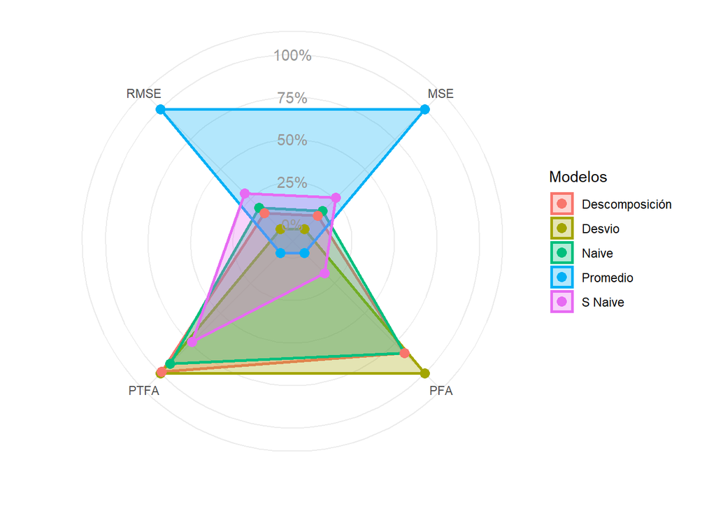

```r
grafico.errores(errores)
```

```r
predicciones <- ts.union(
  serie.btc.train, Original = serie.btc.test,
  'promedio' =       pred.promedio$mean,
  'Naive' =          pred.naive$mean,
  'S Naive' =        pred.snaive$mean,
  'Desvio' =         pred.drift$mean,
  'Descomposición' = pred.stl$mean
)


predicciones <- xts(xts(predicciones, order.by = as.Date(dataset.btc$Date)))

dygraphs::dygraph(predicciones, main = "Predicción del precio del Bitcoin mensual con modelos básicos", width = "100%") %>%
  dyRangeSelector() %>%
  dyLegend(show = "follow", width = 800) %>%
  dyUnzoom() %>%
  dyCrosshair(direction = "vertical") %>%
  dyRangeSelector(height = 20, strokeColor = "black", fillColor = "black")
```

[interactive chart not shown]

## 3.7 **Construcción de modelado avanzados**

### 3.7.1 Holt-Winters

```r
metodo.holtw <- stats::HoltWinters(serie.btc.train)
pred.holtw   <- forecast(metodo.holtw, h = frecuency_parameter) #n.ahead
```

#### 3.7.1.1 Calibración Holt-Winters

```r
library(stats)
library(forecast)

calibrar.HW(serie.btc.train, serie.btc.test)
```

```
## Holt-Winters exponential smoothing with trend and additive seasonal component.
##
## Call:
## HoltWinters(x = datos, alpha = 0.5, beta = 0.8, gamma = 1)
##
## Smoothing parameters:
##  alpha: 0.5
##  beta : 0.8
##  gamma: 1
##
## Coefficients:
##           [,1]
## a    8214.6415
## b    1277.6417
## s1  -2399.6643
## s2  -1665.1703
## s3    504.5667
## s4   1636.9827
## s5   1606.8033
## s6    515.0617
## s7   -600.5958
## s8  -1223.1674
## s9   -436.2543
## s10   205.4796
## s11  1983.0700
## s12  1452.9097
```

```r
metodo.holtw.calibrado <- stats::HoltWinters(serie.btc.train, alpha = 0.5, beta = 0.8,  gamma = 1)
pred.holtw.calibrado   <-   forecast(metodo.holtw.calibrado, h = frecuency_parameter) #n.ahead
```

### 3.7.2 Redes Neuronales

```r
library(stats)
library(forecast)

metodo.nnet <- nnetar(serie.btc.train, size =30)
pred.nnet <- forecast(metodo.nnet, h = frecuency_parameter, PI = T)
```

### 3.7.3 Arima

#### 3.7.3.1 Autocorrelación Simple y Autocorrelación Parcial

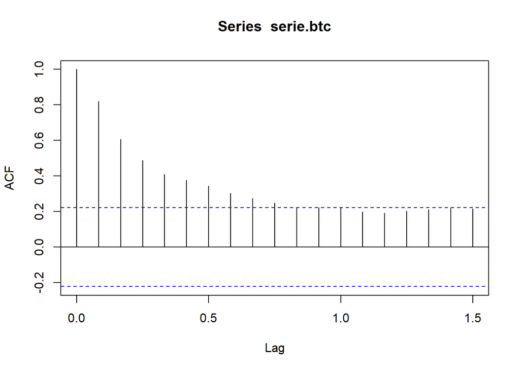

```r
acf(serie.btc)
```

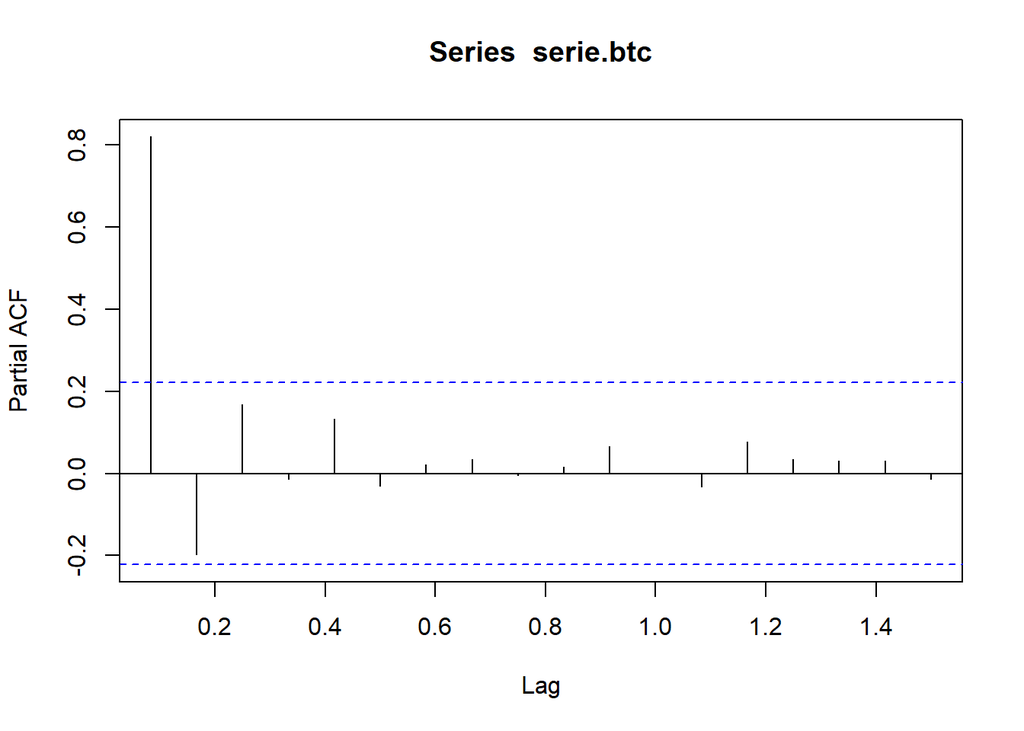

```r
pacf(serie.btc)
```